# Réplica y actualización del paper de Rodrik (2008), cómo usar la PWT con R

Omar Alfaro-Rivera

31/8/2020

En el documento de 2008 de Dani Rodrik ( *The Real Exchange Rate and Economic Growth* ), se vislumbra un análisis sobre los mecanismos que entran en juego para que una depreciación en el Tipo de Cambio Real ( *TCR*, en adelante) pueda mostrar un efecto positivo en el producto. La primera parte de la propuesta de Rodrik tiene un caracter puramente empirico.

Al utilizar los datos de [Penn World Table](https://www.rug.nl/ggdc/productivity/pwt/?lang=en) 6.2, Rodrik encuentra una correlación estadísticamente significativa entre los países en desarrollo que muestran una constante subvaluación del TCR y un crecimiento en el producto. A lo largo de las siguientes secciones se realiza una revisión de los conceptos económicos y de la manipulación de los datos que permiten la réplica de dicho documento, así como un modesto intento por actualizar el documento con los datos más recientes de la *PWT* .

## Obtención de los datos

Una de las facilidades que brinda *R* como ambiente detrabajo para la manipulación de datos,es que su gran comunidad generar constantes desarrollos que benefincian a una buena cantidad de personas. Tal es el caso de la libreria [*“pwt9”*](https://cran.r-project.org/web/packages/pwt/index.html), la cual permite una descarga automática al ambiente de trabajo de las versiones 5.6 hasta la 7.1, y en sus constantes actualizaciones permite contar con todas las últimas versiones de esta valiosa base de datos.

## Efecto Balassa-Samuelson

Para Dani Rodrik el *TCR* está definido como el ratio entre los precio de los bienes comerciables con el extranjero con respecto a los precios domesticos (no comerciables), es decir:

$$ln RER_{i,t} = ln(XRAT_{i,t}/PPP_{i,t})$$
Donde *i* es el indice del país en cuestión y *t* señala un quinquenio (esto es importante, en el documento los datos se trabajan como un panel quinquenal). Para ajustar por el efecto Balassa Samuelson, la siguiente espefificación permite realizar una aproximación a la magnitud del efecto, es decir, en que magnitud el nivel de precios de equilibrio está influenciado por el producto:
$$ln RER_{i,t} = \alpha + \beta lnRGDPCH_{i,t}+f_t+u_{i,t}$$
En la siguientes subsecciones el objetivo es realizar estas estimaciones con los datos utilizados por el autor y contrastar con los datos más recientes disponibles.

### PWT 6.2

La siguiente parte del código muestra las manipulaciones necesarias para realizar las especificaciones econométricas en ela *PWT6.2*.

```r
#La siguiente parte del código utiliza la libreria dplyr, hay abudantes recursos en la red acerca del '%>%'. LA función mutate nos ayuda a generar nuevas variables dentro del Data Frame
pwt6.2 <- pwt6.2 %>%
  mutate( lnRER = log(p^-1), #Como el autor lo señala, 'p' es es una manera más completa de calcular lnRER
          lnRGDPCH = log(rgdpch))

pwt6.2$initial_Y = lag(pwt6.2$lnRGDPCH,5)
#Calcula la tasa de crecimiento promedio por quinquenio

pwt6.2 = pwt6.2 %>%
  group_by(country)%>%
  mutate(Delta_GDP = c(NA,NA,NA,NA,diff(lnRGDPCH,lag = 4)/4))


#Filtra unicamente los años pertenecientes a los años que terminan en 0 y 5, tal y como Rodrik delimita sus quinquenios
pwt62q = pwt6.2 %>%
  filter(str_sub(year,4) %in% c("4", "9"))
#Realiza la regresión
reg1 <- lm(lnRER ~ lnRGDPCH + factor(year), data = pwt62q)
```

### PWT 9.1

```r
pwt91 <- pwt9.1 %>%
  filter(str_sub(year,4) %in% c("4", "9"))%>%
  mutate(rgdpch = rgdpna/pop,
         lnRGDPCH = log(rgdpch),
       lnRER = log((pl_gdpo^-1)))
reg2 <- lm(lnRER ~ lnRGDPCH + factor(year), data = pwt91)
#summary(reg2)
omit1 =  c('factor\\(year\\)1959',
           'factor\\(year\\)1964',
           'factor\\(year\\)1969',
           'factor\\(year\\)1974',
           'factor\\(year\\)1979',
           'factor\\(year\\)1984',
           'factor\\(year\\)1989',
           'factor\\(year\\)1994',
           'factor\\(year\\)1999',
           'factor\\(year\\)2004',
           'factor\\(year\\)2009',
           'factor\\(year\\)2014')

stargazer('PWT 6.1' = reg1, "PWT 9.1" = reg2, title="PWT6.2", type="html",
          column.labels = c('PWT 6.2', 'PWT 9.1'),
          digits = 2, omit =omit1)
```

**PWT6.2**

|  | *Dependent variable:* |  |
| --- | --- | --- |
|  | lnRER |  |
|  | PWT 6.2 | PWT 9.1 |
|  | (1) | (2) |
| lnRGDPCH | -0.24*** | -0.20*** |
|  | (0.01) | (0.01) |
| Constant | -2.20*** | 3.93*** |
|  | (0.11) | (0.09) |
| Observations | 1,402 | 1,898 |
| R<sup>2</sup> | 0.29 | 0.67 |
| Adjusted R<sup>2</sup> | 0.29 | 0.67 |
| Residual Std. Error | 0.48 (df = 1390) | 0.44 (df = 1884) |
| F Statistic | 51.89*** (df = 11; 1390) | 290.93*** (df = 13; 1884) |
| *Note:* | p<0.1; p<0.05; p<0.01 |  |

## UNDERVAL

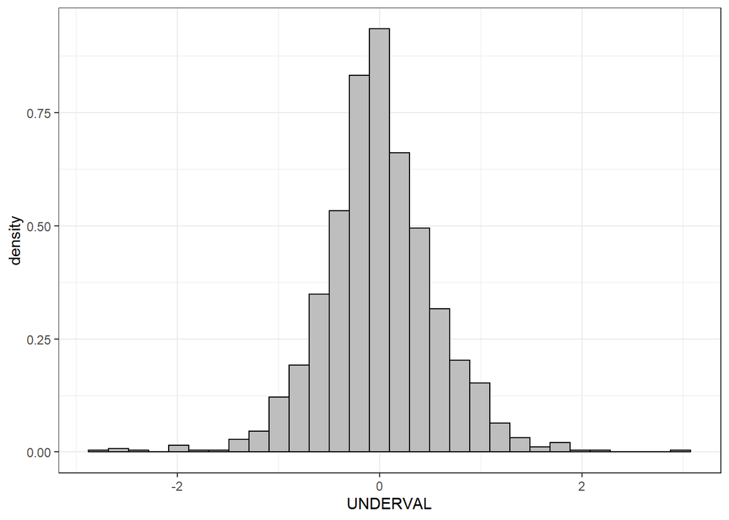

```r
pwt62q$lnRERhat[!is.na(pwt62q$lnRER)] = reg1$fitted.values
pwt62q = pwt62q %>%
  mutate(UNDERVAL = lnRER -lnRERhat)
ggplot(pwt62q)+
  geom_histogram(aes(x=UNDERVAL, y=..density..),
                 fill="gray", colour="black")+
  theme_bw()
```

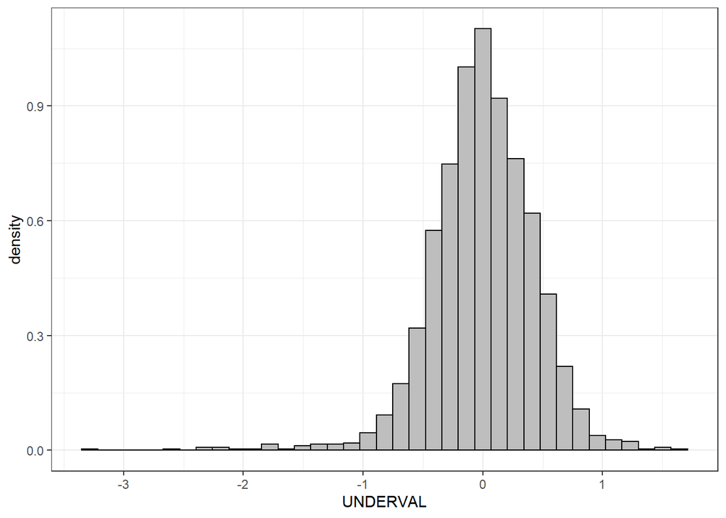

```r
pwt91$lnRERhat[!is.na(pwt91$lnRER)] = reg2$fitted.values
pwt91 = pwt91 %>%
  mutate(UNDERVAL = lnRER -lnRERhat)
ggplot(pwt91)+
  geom_histogram(aes(x=UNDERVAL, y=..density..),
                 fill="gray", colour="black", bins = 37)+
  theme_bw()
```

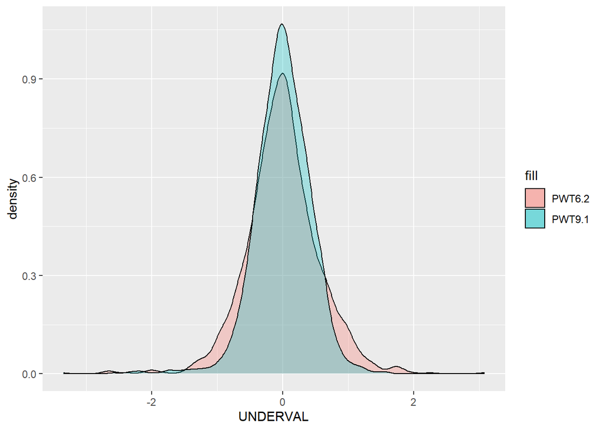

```r
ggplot()+
  geom_density(data=pwt62q, aes(x=UNDERVAL, fill="PWT6.2"), alpha=0.3)+
    geom_density(data=pwt91, aes(x=UNDERVAL, fill="PWT9.1"), alpha=0.3)
```

## Crecimiento y subvaluación

```r
pwt62q = pwt62q %>%
  filter(!(country %in% c('Iraq', 'Laos', 'Korea, Republic of')))

omit2 =  paste('factor\\(country\\)',unique(pwt62q$country), sep = "")

reg3 = lm(Delta_GDP~initial_Y+UNDERVAL+factor(country)+factor(year), data=pwt62q)
#summary(reg3)

reg4 = lm(Delta_GDP~initial_Y+UNDERVAL+factor(country)+factor(year), data=pwt62q[pwt62q$rgdpch<6000,])
#summary(reg4)

stargazer('PWT 6.1' = reg3, "PWT 9.1" = reg4, title="PWT6.2", type="html",
          column.labels = c('PWT 6.2', 'PWT 9.1'),
          digits = 2, omit =c(omit1,omit2))
```

**PWT6.2**

|  | *Dependent variable:* |  |
| --- | --- | --- |
|  | Delta_GDP |  |
|  | PWT 6.2 | PWT 9.1 |
|  | (1) | (2) |
| initial_Y | -0.03*** | -0.04*** |
|  | (0.003) | (0.01) |
| UNDERVAL | 0.004 | 0.01** |
|  | (0.003) | (0.004) |
| Constant | 0.23*** | 0.32*** |
|  | (0.03) | (0.05) |
| Observations | 1,223 | 723 |
| R<sup>2</sup> | 0.35 | 0.36 |
| Adjusted R<sup>2</sup> | 0.23 | 0.20 |
| Residual Std. Error | 0.04 (df = 1032) | 0.04 (df = 581) |
| F Statistic | 2.90*** (df = 190; 1032) | 2.32*** (df = 141; 581) |
| *Note:* | p<0.1; p<0.05; p<0.01 |  |